# **Project - Supervised Learning - AIML - Aishik Sengupta**

## **Data Description** :

The file Bank.xls contains data on 5000 customers. The data include customer demographic information (age, income, etc.), the customer's relationship with the bank (mortgage, securities account, etc.), and the customer response to the last personal loan campaign (Personal Loan). Among these 5000 customers, only 480 (= 9.6%) accepted the personal loan that was offered to them in the earlier campaign.

## **Domain** :

Banking

## **Context**:

This case is about a bank (Thera Bank) whose management wants to explore ways of converting its liability customers to personal loan customers (while retaining them as depositors). A campaign that the bank ran last year for liability customers showed a healthy conversion rate of over 9% success. This has encouraged the retail marketing department to devise campaigns with better target marketing to increase the success ratio with minimal budget.

## **Attribute Information** :

**ID** : Customer ID  
**Age** : Customer's age in completed years  
**Experience** : #years of professional experience  
**Income** : Annual income of the customer (thousand USD)  
**ZIP code** : Home Address ZIP code.  
**Family** : Family size of the customer  
**CCAvg** : Avg. spending on credit cards per month (thousand USD)  
**Education** : Education Level. 1: Undergrad; 2: Graduate; 3: Advanced/Professional  
**Mortgage** : Value of house mortgage if any. (thousand USD)  
**Personal Loan** : Did this customer accept the personal loan offered in the last campaign?  
**Securities Account** : Does the customer have a securities account with the bank?  
**CD Account** : Does the customer have a certificate of deposit (CD) account with the bank?  
**Online** : Does the customer use internet banking facilities?  
**Credit Card** : Does the customer use a credit card issued by UniversalBank?

## **Learning Outcomes**:

- Exploratory Data Analysis
- Preparing the data to train a model
- Training and making predictions using a classification model
- Model evaluation

## **Objective** :

The classification goal is to predict the likelihood of a liability customer buying personal loans.

## **Steps and tasks**:

1. Read the column description and ensure you understand each attribute well
2. Study the data distribution in each attribute, share your findings (15 marks)
3. Get the target column distribution. Your comments (5 marks)
4. Split the data into training and test set in the ratio of 70:30 respectively (5 marks)
5. Use different classification models (Logistic, K-NN and Naïve Bayes) to predict the likelihood of a customer buying personal loans (15 marks)
6. Print the confusion matrix for all the above models (5 marks)
7. Give your reasoning on which is the best model in this case and why it performs better? (5 marks)

```python
import numpy as np # for performing array functions
import pandas as pd # for using data-structures and data-analysis tools
import seaborn as sns # a python data visualization library based on matplotlib
import matplotlib.pyplot as plt # a plotting library for Python

# for automatic plots
%matplotlib inline

# For preprocessing the data
from sklearn import preprocessing # package provides several common utility functions and transformer classes

from sklearn import metrics # to get various evauation metrics
from sklearn.metrics import roc_auc_score # receiver operating curve score

from sklearn.metrics import accuracy_score # accuracy of prediction score
from sklearn.metrics import recall_score # recall score
from sklearn.metrics import precision_score # precision score
from sklearn.metrics import f1_score # f1 score

from sklearn import model_selection # package to select model from
from sklearn.model_selection import train_test_split # function to split data into train and test
from sklearn.linear_model import LogisticRegression # Logistic Regression function
from sklearn.neighbors import KNeighborsClassifier## KNN function
from sklearn.naive_bayes import GaussianNB # using Gaussian algorithm from Naive Bayes

from sklearn.preprocessing import MinMaxScaler # Using Min-Max scaling
from sklearn.preprocessing import StandardScaler # Using standard scaling using variance and standard deviation
from sklearn.model_selection import ShuffleSplit # Random permutation cross-validator
```

```python
# Read the given dataset as a data frame
pl_data = pd.read_csv('Bank_Personal_Loan_Modelling.csv')
```

```python
# Checking out the first five samples of data
pl_data.head()
```

|  | ID | Age | Experience | Income | ZIP Code | Family | CCAvg | Education | Mortgage | Personal Loan | Securities Account | CD Account | Online | CreditCard |
| --- | --- | --- | --- | --- | --- | --- | --- | --- | --- | --- | --- | --- | --- | --- |
| 0 | 1 | 25 | 1 | 49 | 91107 | 4 | 1.6 | 1 | 0 | 0 | 1 | 0 | 0 | 0 |
| 1 | 2 | 45 | 19 | 34 | 90089 | 3 | 1.5 | 1 | 0 | 0 | 1 | 0 | 0 | 0 |
| 2 | 3 | 39 | 15 | 11 | 94720 | 1 | 1.0 | 1 | 0 | 0 | 0 | 0 | 0 | 0 |
| 3 | 4 | 35 | 9 | 100 | 94112 | 1 | 2.7 | 2 | 0 | 0 | 0 | 0 | 0 | 0 |
| 4 | 5 | 35 | 8 | 45 | 91330 | 4 | 1.0 | 2 | 0 | 0 | 0 | 0 | 0 | 1 |

## Exploratory Data Analysis

```python
# getting the 5 point summary and checking the count, mean and standard deviation of data
pl_data.describe().T
```

|  | count | mean | std | min | 25% | 50% | 75% | max |
| --- | --- | --- | --- | --- | --- | --- | --- | --- |
| ID | 5000.0 | 2500.500000 | 1443.520003 | 1.0 | 1250.75 | 2500.5 | 3750.25 | 5000.0 |
| Age | 5000.0 | 45.338400 | 11.463166 | 23.0 | 35.00 | 45.0 | 55.00 | 67.0 |
| Experience | 5000.0 | 20.104600 | 11.467954 | -3.0 | 10.00 | 20.0 | 30.00 | 43.0 |
| Income | 5000.0 | 73.774200 | 46.033729 | 8.0 | 39.00 | 64.0 | 98.00 | 224.0 |
| ZIP Code | 5000.0 | 93152.503000 | 2121.852197 | 9307.0 | 91911.00 | 93437.0 | 94608.00 | 96651.0 |
| Family | 5000.0 | 2.396400 | 1.147663 | 1.0 | 1.00 | 2.0 | 3.00 | 4.0 |
| CCAvg | 5000.0 | 1.937938 | 1.747659 | 0.0 | 0.70 | 1.5 | 2.50 | 10.0 |
| Education | 5000.0 | 1.881000 | 0.839869 | 1.0 | 1.00 | 2.0 | 3.00 | 3.0 |
| Mortgage | 5000.0 | 56.498800 | 101.713802 | 0.0 | 0.00 | 0.0 | 101.00 | 635.0 |
| Personal Loan | 5000.0 | 0.096000 | 0.294621 | 0.0 | 0.00 | 0.0 | 0.00 | 1.0 |
| Securities Account | 5000.0 | 0.104400 | 0.305809 | 0.0 | 0.00 | 0.0 | 0.00 | 1.0 |
| CD Account | 5000.0 | 0.060400 | 0.238250 | 0.0 | 0.00 | 0.0 | 0.00 | 1.0 |
| Online | 5000.0 | 0.596800 | 0.490589 | 0.0 | 0.00 | 1.0 | 1.00 | 1.0 |
| CreditCard | 5000.0 | 0.294000 | 0.455637 | 0.0 | 0.00 | 0.0 | 1.00 | 1.0 |

- Experience has some negative values. We will check that later for data preprocessing. It might have caused error during data collection to out a minus before data.
- Age and Experience have almost same mean and median values, signifying a near normal distribution
- Most people dont have Personal loan, Securities Account and CD Account
- More than 50% people dont have Mortgage and Credit card
- More than 50% people use Online Banking services
- Most people live in 5 digit zip codes starting with 9
- The standard deviation of ZIP code and Mortgage is high

```python
# Checking for any missing values
np.any(np.isnan(pl_data))
```

```
False
```

```python
#Checking if all the values are finite
np.all(np.isfinite(pl_data))
```

```
True
```

#### The attributes can be divided accordingly :

- The variable ID does not add any interesting information. There is no association between a person's customer ID and loan, also it does not provide any general conclusion for future potential loan customers. We can neglect this information for our model prediction.

#### The binary category have five variables as below:

- Personal Loan - Did this customer accept the personal loan offered in the last campaign? This is our target variable
- Securities Account
- CD Account
- Online
- Credit Card

#### Interval variables are as below:

- Age
- Experience
- Income
- CCAvg
- Mortage

#### Ordinal Categorical Variables are:

- Family
- Education

#### The nominal variables are:

- ID
- ZIP Code

```python
# Data to show number of entries in each attribute along with nullable datatype and type of data
pl_data.info()
```

```
<class 'pandas.core.frame.DataFrame'>
RangeIndex: 5000 entries, 0 to 4999
Data columns (total 14 columns):
ID                    5000 non-null int64
Age                   5000 non-null int64
Experience            5000 non-null int64
Income                5000 non-null int64
ZIP Code              5000 non-null int64
Family                5000 non-null int64
CCAvg                 5000 non-null float64
Education             5000 non-null int64
Mortgage              5000 non-null int64
Personal Loan         5000 non-null int64
Securities Account    5000 non-null int64
CD Account            5000 non-null int64
Online                5000 non-null int64
CreditCard            5000 non-null int64
dtypes: float64(1), int64(13)
memory usage: 547.0 KB
```

```python
i=0
while i < len(pl_data.columns): # looping to get each data type of the columns
    print (f'The data type of column {pl_data.columns[i]} is {pl_data.dtypes[i]}' )
    i+=1
```

```
The data type of column ID is int64
The data type of column Age is int64
The data type of column Experience is int64
The data type of column Income is int64
The data type of column ZIP Code is int64
The data type of column Family is int64
The data type of column CCAvg is float64
The data type of column Education is int64
The data type of column Mortgage is int64
The data type of column Personal Loan is int64
The data type of column Securities Account is int64
The data type of column CD Account is int64
The data type of column Online is int64
The data type of column CreditCard is int64
```

```python
#Checking the correlation / association of data among each attributes
pl_data.corr()
```

|  | ID | Age | Experience | Income | ZIP Code | Family | CCAvg | Education | Mortgage | Personal Loan | Securities Account | CD Account | Online | CreditCard |
| --- | --- | --- | --- | --- | --- | --- | --- | --- | --- | --- | --- | --- | --- | --- |
| ID | 1.000000 | -0.008473 | -0.008326 | -0.017695 | 0.013432 | -0.016797 | -0.024675 | 0.021463 | -0.013920 | -0.024801 | -0.016972 | -0.006909 | -0.002528 | 0.017028 |
| Age | -0.008473 | 1.000000 | 0.994215 | -0.055269 | -0.029216 | -0.046418 | -0.052012 | 0.041334 | -0.012539 | -0.007726 | -0.000436 | 0.008043 | 0.013702 | 0.007681 |
| Experience | -0.008326 | 0.994215 | 1.000000 | -0.046574 | -0.028626 | -0.052563 | -0.050077 | 0.013152 | -0.010582 | -0.007413 | -0.001232 | 0.010353 | 0.013898 | 0.008967 |
| Income | -0.017695 | -0.055269 | -0.046574 | 1.000000 | -0.016410 | -0.157501 | 0.645984 | -0.187524 | 0.206806 | 0.502462 | -0.002616 | 0.169738 | 0.014206 | -0.002385 |
| ZIP Code | 0.013432 | -0.029216 | -0.028626 | -0.016410 | 1.000000 | 0.011778 | -0.004061 | -0.017377 | 0.007383 | 0.000107 | 0.004704 | 0.019972 | 0.016990 | 0.007691 |
| Family | -0.016797 | -0.046418 | -0.052563 | -0.157501 | 0.011778 | 1.000000 | -0.109275 | 0.064929 | -0.020445 | 0.061367 | 0.019994 | 0.014110 | 0.010354 | 0.011588 |
| CCAvg | -0.024675 | -0.052012 | -0.050077 | 0.645984 | -0.004061 | -0.109275 | 1.000000 | -0.136124 | 0.109905 | 0.366889 | 0.015086 | 0.136534 | -0.003611 | -0.006689 |
| Education | 0.021463 | 0.041334 | 0.013152 | -0.187524 | -0.017377 | 0.064929 | -0.136124 | 1.000000 | -0.033327 | 0.136722 | -0.010812 | 0.013934 | -0.015004 | -0.011014 |
| Mortgage | -0.013920 | -0.012539 | -0.010582 | 0.206806 | 0.007383 | -0.020445 | 0.109905 | -0.033327 | 1.000000 | 0.142095 | -0.005411 | 0.089311 | -0.005995 | -0.007231 |
| Personal Loan | -0.024801 | -0.007726 | -0.007413 | 0.502462 | 0.000107 | 0.061367 | 0.366889 | 0.136722 | 0.142095 | 1.000000 | 0.021954 | 0.316355 | 0.006278 | 0.002802 |
| Securities Account | -0.016972 | -0.000436 | -0.001232 | -0.002616 | 0.004704 | 0.019994 | 0.015086 | -0.010812 | -0.005411 | 0.021954 | 1.000000 | 0.317034 | 0.012627 | -0.015028 |
| CD Account | -0.006909 | 0.008043 | 0.010353 | 0.169738 | 0.019972 | 0.014110 | 0.136534 | 0.013934 | 0.089311 | 0.316355 | 0.317034 | 1.000000 | 0.175880 | 0.278644 |
| Online | -0.002528 | 0.013702 | 0.013898 | 0.014206 | 0.016990 | 0.010354 | -0.003611 | -0.015004 | -0.005995 | 0.006278 | 0.012627 | 0.175880 | 1.000000 | 0.004210 |
| CreditCard | 0.017028 | 0.007681 | 0.008967 | -0.002385 | 0.007691 | 0.011588 | -0.006689 | -0.011014 | -0.007231 | 0.002802 | -0.015028 | 0.278644 | 0.004210 | 1.000000 |

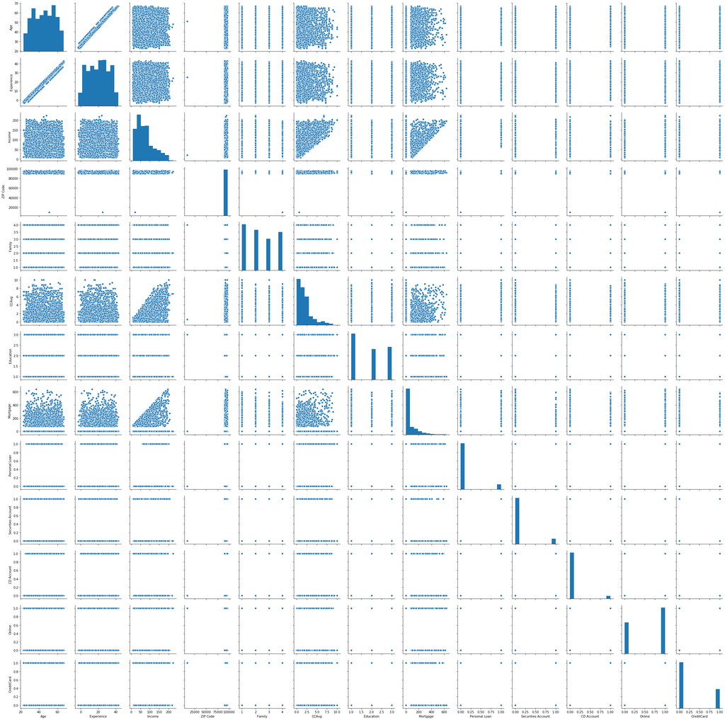

```python
# Getting the pairplot
sns.pairplot( pl_data.iloc[:,1:])
```

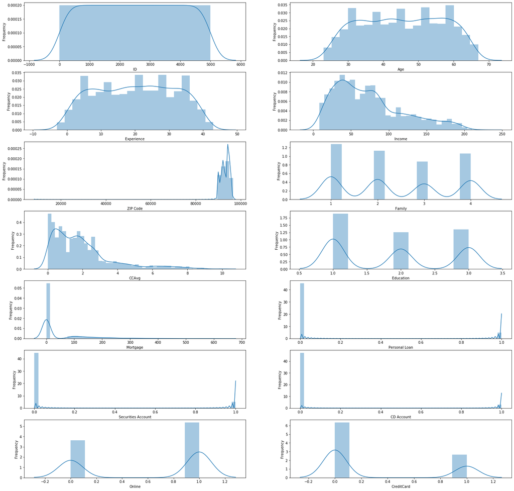

```python
# Getting the distribution of each attribute

plt.figure(figsize= (25,25))
i=0
no_of_cols = pl_data.shape[1]
while i < no_of_cols: # looping to get distribution plot of mentioned columns
    plt.subplot(no_of_cols/2,2,i+1)
    sns.distplot(pl_data[pl_data.columns[i]])
    #plt.title(f'Distribution of {pl_data.columns[i]} \u03bc = {round(pl_data[pl_data.columns[i]].mean(), 3)} & SE = {round(pl_data[pl_data.columns[i]].std(),3)}')
    plt.xlabel(f'{pl_data.columns[i]}')
    plt.ylabel('Frequency')
    i+=1

plt.show()
```

```python
# Checking for skewness

i=0
while i < len(pl_data.columns): # looping to get skewness of mentioned columns
    print(f'The skewness value of {pl_data.columns[i]} is {pl_data[pl_data.columns[i]].skew()}')
    i+=1
```

```
The skewness value of ID is 0.0
The skewness value of Age is -0.02934068151284029
The skewness value of Experience is -0.026324688402384513
The skewness value of Income is 0.8413386072610816
The skewness value of ZIP Code is -12.500221098132892
The skewness value of Family is 0.15522066944367582
The skewness value of CCAvg is 1.5984433366678663
The skewness value of Education is 0.22709331566088503
The skewness value of Mortgage is 2.1040023191079444
The skewness value of Personal Loan is 2.743606655894059
The skewness value of Securities Account is 2.588268372959341
The skewness value of CD Account is 3.6917137984151887
The skewness value of Online is -0.3947853269234487
The skewness value of CreditCard is 0.9045894514231758
```

## Inferences

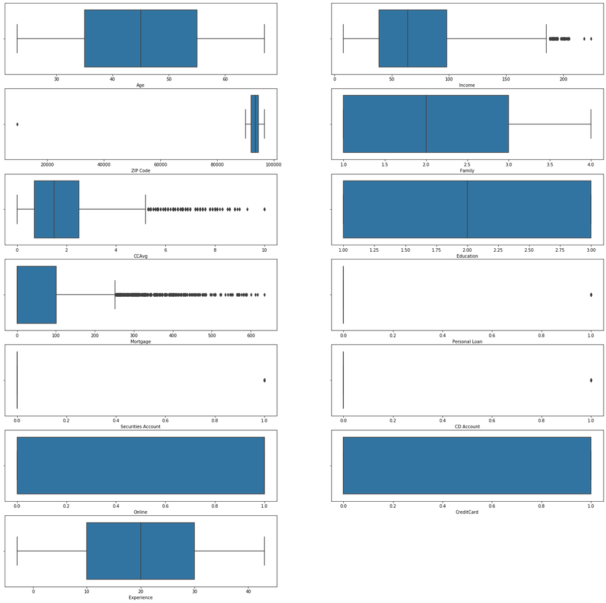

```
There are no Outliers present in Age column
There are Outliers present in Income column
There are Outliers present in ZIP Code column
There are no Outliers present in Family column
There are Outliers present in CCAvg column
There are no Outliers present in Education column
There are Outliers present in Mortgage column
There are Outliers present in Personal Loan column
There are Outliers present in Securities Account column
There are Outliers present in CD Account column
There are no Outliers present in Online column
There are no Outliers present in CreditCard column
There are no Outliers present in Experience column
```

```python
# Checking for Outliers

plt.figure(figsize= (25,25))

lower_bound = 0
upper_bound = 0
check_presence_outliers = ''
columns = ["Age","Income","ZIP Code","Family","CCAvg","Education","Mortgage","Personal Loan","Securities Account","CD Account","Online","CreditCard","Experience"]
i=0
while i < len(columns): # get boxplots of each column

    # Checking through Plots
    plt.subplot(7,2,i+1)
    sns.boxplot(pl_data[columns[i]])
    #plt.title(f'Boxplot of {columns[i]}')
    plt.xlabel(f'{columns[i]}')


    q1,q3 = np.percentile(pl_data[columns[i]],[25,75]) # get 1st and 3rd quartile
    iqr = q3 - q1 # get inter-quartile range
    lower_bound = q1 -(1.5 * iqr) # get lower bound
    upper_bound = q3 +(1.5 * iqr) # get outer bound

    # Checking through series data
    if (pl_data[columns[i]]<lower_bound).any() or (pl_data[columns[i]]>upper_bound).any() :
        check_presence_outliers += f'There are Outliers present in {columns[i]} column \n'
    else :
        check_presence_outliers += f'There are no Outliers present in {columns[i]} column \n'

    i+=1

plt.show()

print(check_presence_outliers)
```

## Target Column Distribution - Personal Loan

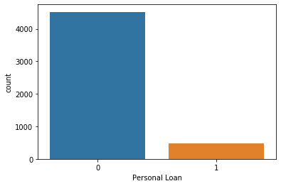

```python
# Distribution Of Personal Loan
sns.countplot(pl_data['Personal Loan'],label="Count")
```

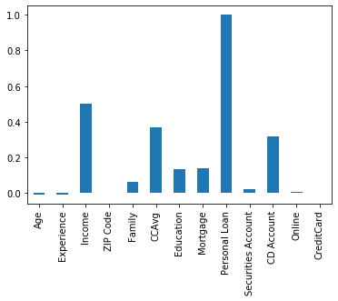

```python
# Checking the correlation of attributes with target
pl_data.corr()['Personal Loan'][1:].plot.bar();
```

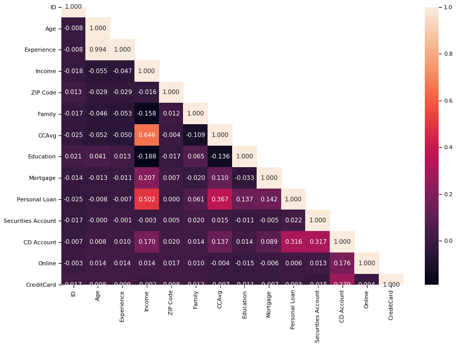

```python
corr = pl_data.corr()
sns.set_context("notebook", font_scale=1.0, rc={"lines.linewidth": 2.5})
plt.figure(figsize=(15,10))
# create a mask so we only see the correlation values once
mask = np.zeros_like(corr)
mask[np.triu_indices_from(mask, 1)] = True
a = sns.heatmap(corr,mask=mask, annot=True, fmt='.3f')
#rotx = a.set_xticklabels(a.get_xticklabels(), rotation=90)
#roty = a.set_yticklabels(a.get_yticklabels(), rotation=30)
```

### Influence of income and education on personal loan

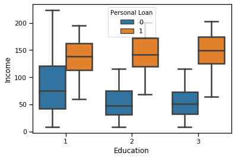

```python
sns.boxplot(x='Education',y='Income',hue='Personal Loan',data=pl_data)
```

It seems the customers whose education level is 1 is having more income. However customers who has taken the personal loan have the same income levels. We can say that the proportion of persons who has Personal Loan among them who has Third and Second Level of Education is higher than proportion among people who has First level of Edication

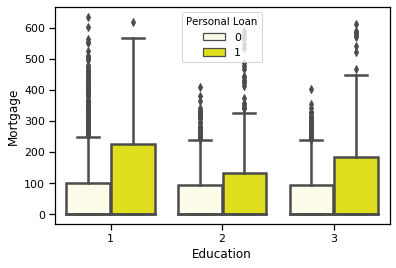

```python
sns.boxplot(x="Education", y='Mortgage', hue="Personal Loan", data=pl_data,color='yellow')
```

Across all education levels , customers who took personal loan have high mortgages.

### Influence of Securities account on personal loan

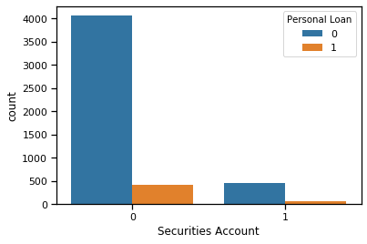

```python
sns.countplot(x="Securities Account", data=pl_data,hue="Personal Loan")
```

Whether you took a personal loan or not, the proportion of having a securities account is the same

### Influence of Family on personal loan

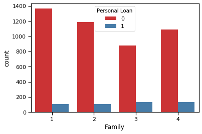

```python
sns.countplot(x='Family',data=pl_data,hue='Personal Loan',palette='Set1')
```

Family size does not have any impact in personal loan. But it seems families with size of 3 are more likely to take loan. When considering future campaign this might be good association.

### Influence of CD Account on personal loan

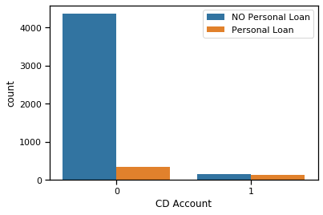

```python
sns.countplot(x='CD Account',data=pl_data,hue='Personal Loan')
plt.legend(('NO Personal Loan', 'Personal Loan'));
```

We may say that the proportion of persons who has Personal Loan among them who has CD account with The Bank is quit high.

### Influence of CCAvg on personal loan

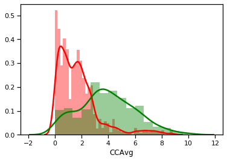

```python
sns.distplot( pl_data[pl_data['Personal Loan'] == 0]['CCAvg'], color = 'r')
sns.distplot( pl_data[pl_data['Personal Loan'] == 1]['CCAvg'], color = 'g')
```

```python
print('Credit card spending of Non-Loan customers: ',pl_data[pl_data['Personal Loan'] == 0]['CCAvg'].median()*1000)
print('Credit card spending of Loan customers    : ', pl_data[pl_data['Personal Loan'] == 1]['CCAvg'].median()*1000)
```

```
Credit card spending of Non-Loan customers:  1400.0
Credit card spending of Loan customers    :  3800.0
```

The graph show persons who have personal loan have a higher credit card average. Average credit card spending with a median of 3800 dollar indicates a higher probability of personal loan. Lower credit card spending with a median of 1400 dollars is less likely to take a loan.

### Influence of income and family on personal loan

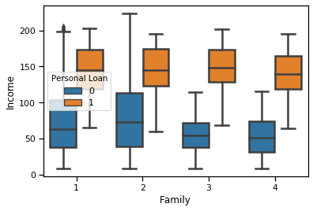

```python
sns.boxplot(x=pl_data.Family,y=pl_data.Income,hue=pl_data['Personal Loan'])
```

Customers who took personal loan have a higher income across all levels of family size

### Negative Experience Cleaning

```python
# Getting absolute value of all data to impute the negative experiences
pl_data["Experience"] = pl_data["Experience"].apply(abs)
```

```python
# Segregating the data having zero experience and positive experience
plExp = pl_data.loc[pl_data['Experience'] > 0]
zeroExpID = pl_data.loc[pl_data['Experience'] == 0]['ID'].tolist()
```

Customers with income cannot have zero experiences

```python
len(zeroExpID) # number of samples having zero samples
```

```
66
```

```python
# setting zero experience values with median experience values from positive experience values having same age and education
for id in zeroExpID:
    age = pl_data.loc[pl_data['ID'] == id]['Age'].tolist()[0]
    education = pl_data.loc[pl_data['ID'] == id]['Education'].tolist()[0]
    df_filtered = plExp[(plExp.Age == age) & (plExp.Education == education)]
    experience = df_filtered.Experience.median()
    pl_data.loc[pl_data['ID'] == id,'Experience'] = experience
```

```python
pl_data.describe().T
```

|  | count | mean | std | min | 25% | 50% | 75% | max |
| --- | --- | --- | --- | --- | --- | --- | --- | --- |
| ID | 5000.0 | 2500.500000 | 1443.520003 | 1.0 | 1250.75 | 2500.5 | 3750.25 | 5000.0 |
| Age | 5000.0 | 45.338400 | 11.463166 | 23.0 | 35.00 | 45.0 | 55.00 | 67.0 |
| Experience | 5000.0 | 20.152600 | 11.384711 | 1.0 | 10.00 | 20.0 | 30.00 | 43.0 |
| Income | 5000.0 | 73.774200 | 46.033729 | 8.0 | 39.00 | 64.0 | 98.00 | 224.0 |
| ZIP Code | 5000.0 | 93152.503000 | 2121.852197 | 9307.0 | 91911.00 | 93437.0 | 94608.00 | 96651.0 |
| Family | 5000.0 | 2.396400 | 1.147663 | 1.0 | 1.00 | 2.0 | 3.00 | 4.0 |
| CCAvg | 5000.0 | 1.937938 | 1.747659 | 0.0 | 0.70 | 1.5 | 2.50 | 10.0 |
| Education | 5000.0 | 1.881000 | 0.839869 | 1.0 | 1.00 | 2.0 | 3.00 | 3.0 |
| Mortgage | 5000.0 | 56.498800 | 101.713802 | 0.0 | 0.00 | 0.0 | 101.00 | 635.0 |
| Personal Loan | 5000.0 | 0.096000 | 0.294621 | 0.0 | 0.00 | 0.0 | 0.00 | 1.0 |
| Securities Account | 5000.0 | 0.104400 | 0.305809 | 0.0 | 0.00 | 0.0 | 0.00 | 1.0 |
| CD Account | 5000.0 | 0.060400 | 0.238250 | 0.0 | 0.00 | 0.0 | 0.00 | 1.0 |
| Online | 5000.0 | 0.596800 | 0.490589 | 0.0 | 0.00 | 1.0 | 1.00 | 1.0 |
| CreditCard | 5000.0 | 0.294000 | 0.455637 | 0.0 | 0.00 | 0.0 | 1.00 | 1.0 |

The Experience column has a minimum of 1 year now.

# Splitting the data into Train & Test

```python
X = pl_data.drop(['ID','Personal Loan'],axis=1)     # Predictor feature columns
y = pl_data['Personal Loan']   # Predicted class (1=True, 0=False)

# Splitting into 30% test data
X_train, X_test, y_train, y_test = train_test_split(X, y, test_size=0.3, random_state=1)
# 1 is just any random seed number

X_train.head()
```

|  | Age | Experience | Income | ZIP Code | Family | CCAvg | Education | Mortgage | Securities Account | CD Account | Online | CreditCard |
| --- | --- | --- | --- | --- | --- | --- | --- | --- | --- | --- | --- | --- |
| 1334 | 47 | 22.0 | 35 | 94304 | 2 | 1.3 | 1 | 0 | 0 | 0 | 1 | 0 |
| 4768 | 38 | 14.0 | 39 | 93118 | 1 | 2.0 | 2 | 0 | 0 | 0 | 1 | 0 |
| 65 | 59 | 35.0 | 131 | 91360 | 1 | 3.8 | 1 | 0 | 0 | 0 | 1 | 1 |
| 177 | 29 | 3.0 | 65 | 94132 | 4 | 1.8 | 2 | 244 | 0 | 0 | 0 | 0 |
| 4489 | 39 | 13.0 | 21 | 95518 | 3 | 0.2 | 2 | 0 | 0 | 0 | 1 | 0 |

```python
print("{0:0.2f}% data is in training set".format((len(X_train)/len(pl_data.index)) * 100))
print("{0:0.2f}% data is in test set".format((len(X_test)/len(pl_data.index)) * 100))
```

```
70.00% data is in training set
30.00% data is in test set
```

```python
print("Original PL True Values    : {0} ({1:0.2f}%)".format(len(pl_data.loc[pl_data['Personal Loan'] == 1]), (len(pl_data.loc[pl_data['Personal Loan'] == 1])/len(pl_data.index)) * 100))
print("Original PL False Values   : {0} ({1:0.2f}%)".format(len(pl_data.loc[pl_data['Personal Loan'] == 0]), (len(pl_data.loc[pl_data['Personal Loan'] == 0])/len(pl_data.index)) * 100))
print("")
print("Training PL True Values    : {0} ({1:0.2f}%)".format(len(y_train[y_train[:] == 1]), (len(y_train[y_train[:] == 1])/len(y_train)) * 100))
print("Training PL False Values   : {0} ({1:0.2f}%)".format(len(y_train[y_train[:] == 0]), (len(y_train[y_train[:] == 0])/len(y_train)) * 100))
print("")
print("Test PL True Values        : {0} ({1:0.2f}%)".format(len(y_test[y_test[:] == 1]), (len(y_test[y_test[:] == 1])/len(y_test)) * 100))
print("Test PL False Values       : {0} ({1:0.2f}%)".format(len(y_test[y_test[:] == 0]), (len(y_test[y_test[:] == 0])/len(y_test)) * 100))
print("")
```

```
Original PL True Values    : 480 (9.60%)
Original PL False Values   : 4520 (90.40%)

Training PL True Values    : 331 (9.46%)
Training PL False Values   : 3169 (90.54%)

Test PL True Values        : 149 (9.93%)
Test PL False Values       : 1351 (90.07%)
```

# Logistic Regression Model

```python
# Fit the model on train
model = LogisticRegression(solver="liblinear")
model.fit(X_train, y_train)
#predict on test data
y_predict = model.predict(X_test)


coef_df = pd.DataFrame(model.coef_)
coef_df['intercept'] = model.intercept_
print(coef_df) # Printing the coefficients
```

```
          0         1         2         3         4         5         6  \
0 -0.000455 -0.002492  0.036086 -0.000066  0.015144  0.009441  0.016423

          7         8         9        10        11  intercept
0  0.000833  0.000534  0.004674 -0.000176 -0.000067  -0.000105
```

```python
print("Accuracy on training set: {:.4f}".format(model.score(X_train, y_train)))
print("Accuracy on test set: {:.4f}".format(model.score(X_test, y_test)))
```

```
Accuracy on training set: 0.9091
Accuracy on test set: 0.9073
```

Both score are similar for training and test, so no scenario of overfitting or underfitting.

```python
# Probability of buying Personal Loan of each customer in dataset
model.predict_proba(X_test)[:,1]
```

```
array([0.05662881, 0.01460717, 0.00743957, ..., 0.00629479, 0.00772513,
       0.00719934])
```

```python
print("Classification Report")
print(metrics.classification_report(y_test, y_predict, labels=[1, 0]))
```

```
Classification Report
              precision    recall  f1-score   support

           1       0.57      0.29      0.38       149
           0       0.93      0.98      0.95      1351

    accuracy                           0.91      1500
   macro avg       0.75      0.63      0.67      1500
weighted avg       0.89      0.91      0.89      1500
```

## Predicting the likelihood of a customer buying personal loan on the LR model we built

```python
# Data of Aishik Sengupta
x_test = {'Age': [25], 'Experience': [3.0], 'Income':[65],'ZIP Code':[91380],'Family':[1],'CCAvg':[3.5],'Education':[2],
          'Mortgage':[0],'Securities Account':[0], 'CD Account':[1],'Online':[1],'CreditCard':[1]}
```

```python
#Taking the data in a data frame
x_testing = pd.DataFrame(data = x_test)
x_testing
```

|  | Age | Experience | Income | ZIP Code | Family | CCAvg | Education | Mortgage | Securities Account | CD Account | Online | CreditCard |
| --- | --- | --- | --- | --- | --- | --- | --- | --- | --- | --- | --- | --- |
| 0 | 25 | 3.0 | 65 | 91380 | 1 | 3.5 | 2 | 0 | 0 | 1 | 1 | 1 |

```python
#predict on test data
y_predicting = model.predict(x_testing)
if ( y_predicting == 1):
    print('Customer will buy Personal Loan')
else:
    print('Customer will not buy Personal Loan')
```

```
Customer will not buy Personal Loan
```

```python
# Predicting the probability
model.predict_proba(x_testing)[:,1]
```

```
array([0.02689614])
```

```python
# Taking ID 48 from dataset
x_test = {'Age': [37], 'Experience': [12.0], 'Income':[194],'ZIP Code':[91380],'Family':[4],'CCAvg':[0.2],'Education':[3],
          'Mortgage':[211],'Securities Account':[1], 'CD Account':[1],'Online':[1],'CreditCard':[1]}
```

```python
#Taking the data in a data frame
x_testing = pd.DataFrame(data = x_test)
x_testing
```

|  | Age | Experience | Income | ZIP Code | Family | CCAvg | Education | Mortgage | Securities Account | CD Account | Online | CreditCard |
| --- | --- | --- | --- | --- | --- | --- | --- | --- | --- | --- | --- | --- |
| 0 | 37 | 12.0 | 194 | 91380 | 4 | 0.2 | 3 | 211 | 1 | 1 | 1 | 1 |

```python
#predict on test data
y_predicting = model.predict(x_testing)
if ( y_predicting == 1):
    print('Customer will buy Personal Loan')
else:
    print('Customer will not buy Personal Loan')
```

```
Customer will buy Personal Loan
```

```python
# Predicting the probability
model.predict_proba(x_testing)[:,1]
```

```
array([0.77654149])
```

## Confusion Matrix

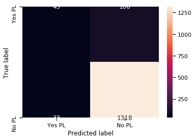

```python
cm=metrics.confusion_matrix(y_test, y_predict, labels=[1, 0])

df_cm = pd.DataFrame(cm, index = [i for i in ["1","0"]],
                  columns = [i for i in ["Predict 1","Predict 0"]])
sns.heatmap(df_cm, annot=True, fmt='.0f', xticklabels = ["Yes PL", "No PL"] , yticklabels = ["Yes PL", "No PL"])
plt.ylabel('True label')
plt.xlabel('Predicted label')
```

```python
df_cm # confusion matrix
```

|  | Predict 1 | Predict 0 |
| --- | --- | --- |
| 1 | 43 | 106 |
| 0 | 33 | 1318 |

### Confusion Matrix parameters

True Positives (TP): we correctly predicted that they did take the Personal Loan - 43

True Negatives (TN): we correctly predicted that they didnt take the Personal Loan - 1318

False Positives (FP): we incorrectly predicted that they did take the Personal Loan (a "Type I error") 33 Falsely predict positive Type I error

False Negatives (FN): we incorrectly predicted that they didnt take the Personal Loan (a "Type II error") 106 Falsely predict negative Type II error

```python
print(f'Accuracy Score : {accuracy_score(y_test, y_predict)} ')
print(f'Precision Score : {precision_score(y_test, y_predict)}')
print(f'Recall Score : {recall_score(y_test, y_predict)}')
print(f'F1 Score : {f1_score(y_test, y_predict)}')
```

```
Accuracy Score : 0.9073333333333333
Precision Score : 0.5657894736842105
Recall Score : 0.28859060402684567
F1 Score : 0.38222222222222224
```

```python
# Gettin the ROC curve score
roc_auc_score(y_test, y_predict)
```

```
0.632082126587812
```

## Scaling the data using Standard Scaler to improve Logistic Regression Performance

```python
X = pl_data.drop(['ID','Personal Loan'],axis=1)     # Predictor feature columns
y = pl_data['Personal Loan']   # Predicted class (1=True, 0=False)

# Splitting into 30% test data
X_train, X_test, y_train, y_test = train_test_split(X, y, test_size=0.3, random_state=1)
# 1 is just any random seed number

X_train.head()
```

|  | Age | Experience | Income | ZIP Code | Family | CCAvg | Education | Mortgage | Securities Account | CD Account | Online | CreditCard |
| --- | --- | --- | --- | --- | --- | --- | --- | --- | --- | --- | --- | --- |
| 1334 | 47 | 22.0 | 35 | 94304 | 2 | 1.3 | 1 | 0 | 0 | 0 | 1 | 0 |
| 4768 | 38 | 14.0 | 39 | 93118 | 1 | 2.0 | 2 | 0 | 0 | 0 | 1 | 0 |
| 65 | 59 | 35.0 | 131 | 91360 | 1 | 3.8 | 1 | 0 | 0 | 0 | 1 | 1 |
| 177 | 29 | 3.0 | 65 | 94132 | 4 | 1.8 | 2 | 244 | 0 | 0 | 0 | 0 |
| 4489 | 39 | 13.0 | 21 | 95518 | 3 | 0.2 | 2 | 0 | 0 | 0 | 1 | 0 |

```python
# Scaling the data using StandardScaler
scaler = StandardScaler()
X_train_scaled = scaler.fit_transform(X_train)
X_test_scaled = scaler.fit_transform(X_test)

# Fit the model on train
model = LogisticRegression(solver="liblinear")
model.fit(X_train_scaled, y_train)
#predict on test data
y_predict = model.predict(X_test_scaled)


coef_df = pd.DataFrame(model.coef_)
coef_df['intercept'] = model.intercept_
print(coef_df) # Printing the coefficients
```

```
          0         1         2         3         4         5         6  \
0 -0.061309  0.114566  2.318803  0.020021  0.778654  0.292742  1.348394

          7       8         9        10        11  intercept
0  0.076794 -0.3415  0.885874 -0.286776 -0.500451  -4.561186
```

```python
model.predict_proba(X_test_scaled)[:,1] # Probability of buying Personal Loan of each customer in dataset
```

```
array([0.02601378, 0.00041322, 0.00079142, ..., 0.00501094, 0.00512966,
       0.00090455])
```

## Getting the score on Training & Test data

```python
print("Accuracy on training set: {:.4f}".format(model.score(X_train_scaled, y_train)))
print("Accuracy on test set: {:.4f}".format(model.score(X_test_scaled, y_test)))
```

```
Accuracy on training set: 0.9534
Accuracy on test set: 0.9473
```

Both score are similar for training and test, so no scenario of overfitting or underfitting.

```python
print("Classification Report")
print(metrics.classification_report(y_test, y_predict, labels=[1, 0]))
```

```
Classification Report
              precision    recall  f1-score   support

           1       0.83      0.59      0.69       149
           0       0.96      0.99      0.97      1351

    accuracy                           0.95      1500
   macro avg       0.89      0.79      0.83      1500
weighted avg       0.94      0.95      0.94      1500
```

### The Confusion Matrix

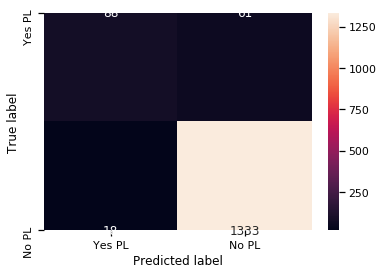

```python
cm=metrics.confusion_matrix(y_test, y_predict, labels=[1, 0])

df_cm = pd.DataFrame(cm, index = [i for i in ["1","0"]],
                  columns = [i for i in ["Predict 1","Predict 0"]])
sns.heatmap(df_cm, annot=True, fmt='.0f', xticklabels = ["Yes PL", "No PL"] , yticklabels = ["Yes PL", "No PL"])
plt.ylabel('True label')
plt.xlabel('Predicted label')
```

```python
df_cm # confusion matrix
```

|  | Predict 1 | Predict 0 |
| --- | --- | --- |
| 1 | 88 | 61 |
| 0 | 18 | 1333 |

### Confusion Matrix parameters

True Positives (TP): we correctly predicted that they did take the Personal Loan - 88

True Negatives (TN): we correctly predicted that they didnt take the Personal Loan - 1333

False Positives (FP): we incorrectly predicted that they did take the Personal Loan (a "Type I error") 18 Falsely predict positive Type I error

False Negatives (FN): we incorrectly predicted that they didnt take the Personal Loan (a "Type II error") 61 Falsely predict negative Type II error

```python
print(f'Accuracy Score : {accuracy_score(y_test, y_predict)} ')
print(f'Precision Score : {precision_score(y_test, y_predict)}')
print(f'Recall Score : {recall_score(y_test, y_predict)}')
print(f'F1 Score : {f1_score(y_test, y_predict)}')
```

```
Accuracy Score : 0.9473333333333334
Precision Score : 0.8301886792452831
Recall Score : 0.5906040268456376
F1 Score : 0.6901960784313727
```

```python
# Gettin the ROC curve score
roc_auc_score(y_test, y_predict)
```

```
0.7886402813724857
```

# Naive Bayes Model

#### Naive Bayes Model Performance does not increase using any form of scaling on its model

```python
X = pl_data.drop(['ID','Personal Loan'],axis=1)     # Predictor feature columns
y = pl_data['Personal Loan']   # Predicted class (1=True, 0=False)

# Splitting into 30% test data
X_train, X_test, y_train, y_test = train_test_split(X, y, test_size=0.3, random_state=1)
# 1 is just any random seed number

X_train.head()
```

|  | Age | Experience | Income | ZIP Code | Family | CCAvg | Education | Mortgage | Securities Account | CD Account | Online | CreditCard |
| --- | --- | --- | --- | --- | --- | --- | --- | --- | --- | --- | --- | --- |
| 1334 | 47 | 22.0 | 35 | 94304 | 2 | 1.3 | 1 | 0 | 0 | 0 | 1 | 0 |
| 4768 | 38 | 14.0 | 39 | 93118 | 1 | 2.0 | 2 | 0 | 0 | 0 | 1 | 0 |
| 65 | 59 | 35.0 | 131 | 91360 | 1 | 3.8 | 1 | 0 | 0 | 0 | 1 | 1 |
| 177 | 29 | 3.0 | 65 | 94132 | 4 | 1.8 | 2 | 244 | 0 | 0 | 0 | 0 |
| 4489 | 39 | 13.0 | 21 | 95518 | 3 | 0.2 | 2 | 0 | 0 | 0 | 1 | 0 |

```python
# create the model
model = GaussianNB()

model.fit(X_train, y_train.ravel())
```

```
GaussianNB(priors=None, var_smoothing=1e-09)
```

```python
print("Accuracy on training set: {:.4f}".format(model.score(X_train, y_train)))
print("Accuracy on test set: {:.4f}".format(model.score(X_test, y_test)))
```

```
Accuracy on training set: 0.8943
Accuracy on test set: 0.8840
```

Both score are similar for training and test, so no scenario of overfitting or underfitting.

```python
y_predict = model.predict(X_test) # getting the prediction on test data
```

```python
model.predict_proba(X_test)[:,1] # Probability of buying Personal Loan of each customer in dataset
```

```
array([5.61959431e-03, 4.63048668e-05, 1.32537637e-05, ...,
       4.65857666e-06, 2.67929206e-05, 2.31780794e-05])
```

```python
print("Classification Report")
print(metrics.classification_report(y_test, y_predict, labels=[1, 0]))
```

```
Classification Report
              precision    recall  f1-score   support

           1       0.44      0.57      0.49       149
           0       0.95      0.92      0.93      1351

    accuracy                           0.88      1500
   macro avg       0.69      0.74      0.71      1500
weighted avg       0.90      0.88      0.89      1500
```

## Predicting the likelihood of a customer buying personal loan on the NB model we built

```python
# Data of Aishik Sengupta
x_test = {'Age': [25], 'Experience': [3.0], 'Income':[65],'ZIP Code':[91380],'Family':[1],'CCAvg':[3.5],'Education':[2],
          'Mortgage':[0],'Securities Account':[0], 'CD Account':[1],'Online':[1],'CreditCard':[1]}
```

```python
#Taking the data in a data frame
x_testing = pd.DataFrame(data = x_test)
x_testing
```

|  | Age | Experience | Income | ZIP Code | Family | CCAvg | Education | Mortgage | Securities Account | CD Account | Online | CreditCard |
| --- | --- | --- | --- | --- | --- | --- | --- | --- | --- | --- | --- | --- |
| 0 | 25 | 3.0 | 65 | 91380 | 1 | 3.5 | 2 | 0 | 0 | 1 | 1 | 1 |

```python
#predict on test data
y_predicting = model.predict(x_testing)
if ( y_predicting == 1):
    print('Customer will buy Personal Loan')
else:
    print('Customer will not buy Personal Loan')
```

```
Customer will buy Personal Loan
```

```python
# Predicting the probability
model.predict_proba(x_testing)[:,1]
```

```
array([0.98252279])
```

```python
# Taking ID 48 from dataset
x_test = {'Age': [37], 'Experience': [12.0], 'Income':[194],'ZIP Code':[91380],'Family':[4],'CCAvg':[0.2],'Education':[3],
          'Mortgage':[211],'Securities Account':[1], 'CD Account':[1],'Online':[1],'CreditCard':[1]}
```

```python
#Taking the data in a data frame
x_testing = pd.DataFrame(data = x_test)
x_testing
```

|  | Age | Experience | Income | ZIP Code | Family | CCAvg | Education | Mortgage | Securities Account | CD Account | Online | CreditCard |
| --- | --- | --- | --- | --- | --- | --- | --- | --- | --- | --- | --- | --- |
| 0 | 37 | 12.0 | 194 | 91380 | 4 | 0.2 | 3 | 211 | 1 | 1 | 1 | 1 |

```python
#predict on test data
y_predicting = model.predict(x_testing)
if ( y_predicting == 1):
    print('Customer will buy Personal Loan')
else:
    print('Customer will not buy Personal Loan')
```

```
Customer will buy Personal Loan
```

```python
# Predicting the probability
model.predict_proba(x_testing)[:,1]
```

```
array([0.99999474])
```

### The Confusion Matrix

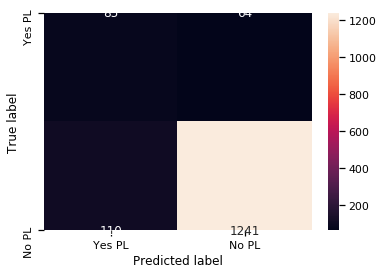

```python
cm=metrics.confusion_matrix(y_test, y_predict, labels=[1, 0])

df_cm = pd.DataFrame(cm, index = [i for i in ["1","0"]],
                  columns = [i for i in ["Predict 1","Predict 0"]])
sns.heatmap(df_cm, annot=True, fmt='.0f', xticklabels = ["Yes PL", "No PL"] , yticklabels = ["Yes PL", "No PL"])
plt.ylabel('True label')
plt.xlabel('Predicted label')
```

```python
df_cm # confusion matrix
```

|  | Predict 1 | Predict 0 |
| --- | --- | --- |
| 1 | 85 | 64 |
| 0 | 110 | 1241 |

### Confusion Matrix Parameters

True Positives (TP): we correctly predicted that they did take the Personal Loan - 85

True Negatives (TN): we correctly predicted that they didnt take the Personal Loan - 1241

False Positives (FP): we incorrectly predicted that they did take the Personal Loan (a "Type I error") 110 Falsely predict positive Type I error

False Negatives (FN): we incorrectly predicted that they didnt take the Personal Loan (a "Type II error") 64 Falsely predict negative Type II error

```python
print(f'Accuracy Score : {accuracy_score(y_test, y_predict)} ')
print(f'Precision Score : {precision_score(y_test, y_predict)}')
print(f'Recall Score : {recall_score(y_test, y_predict)}')
print(f'F1 Score : {f1_score(y_test, y_predict)}')
```

```
Accuracy Score : 0.884
Precision Score : 0.4358974358974359
Recall Score : 0.5704697986577181
F1 Score : 0.4941860465116279
```

```python
roc_auc_score(y_test, y_predict)
```

```
0.7445243145768236
```

# KNN Model

```python
X = pl_data.drop(['ID','Personal Loan'],axis=1)     # Predictor feature columns
y = pl_data['Personal Loan']   # Predicted class (1=True, 0=False)

# Splitting into 30% test data
X_train, X_test, y_train, y_test = train_test_split(X, y, test_size=0.3, random_state=1)
# 1 is just any random seed number

X_train.head()
```

|  | Age | Experience | Income | ZIP Code | Family | CCAvg | Education | Mortgage | Securities Account | CD Account | Online | CreditCard |
| --- | --- | --- | --- | --- | --- | --- | --- | --- | --- | --- | --- | --- |
| 1334 | 47 | 22.0 | 35 | 94304 | 2 | 1.3 | 1 | 0 | 0 | 0 | 1 | 0 |
| 4768 | 38 | 14.0 | 39 | 93118 | 1 | 2.0 | 2 | 0 | 0 | 0 | 1 | 0 |
| 65 | 59 | 35.0 | 131 | 91360 | 1 | 3.8 | 1 | 0 | 0 | 0 | 1 | 1 |
| 177 | 29 | 3.0 | 65 | 94132 | 4 | 1.8 | 2 | 244 | 0 | 0 | 0 | 0 |
| 4489 | 39 | 13.0 | 21 | 95518 | 3 | 0.2 | 2 | 0 | 0 | 0 | 1 | 0 |

```python
# creating odd list of K nearest neighbors for KNN
myList = list(range(1,20))

# subsetting just the odd ones
neighbors = list(filter(lambda x: x % 2 != 0, myList))
neighbors
```

```
[1, 3, 5, 7, 9, 11, 13, 15, 17, 19]
```

```python
# empty list that will hold accuracy scores
ac_scores = []

# perform accuracy metrics for values from 1,3,5....19
for k in neighbors:
    knn = KNeighborsClassifier(n_neighbors=k)
    knn.fit(X_train, y_train)
    # predict the response
    y_predict = knn.predict(X_test)
    # evaluate accuracy
    scores = accuracy_score(y_test, y_predict)
    ac_scores.append(scores)

# changing to misclassification error
MSE = [1 - x for x in ac_scores]

# determining best k
optimal_k = neighbors[MSE.index(min(MSE))]
print("The optimal number of neighbors is %d" % optimal_k)
```

```
The optimal number of neighbors is 3
```

```python
# instantiate learning model
model = KNeighborsClassifier(n_neighbors = optimal_k)

# fitting the model
model.fit(X_train, y_train)

# predict the response
y_predict = model.predict(X_test)
y_predict
```

```
array([0, 0, 0, ..., 0, 0, 0], dtype=int64)
```

```python
model.predict_proba(X_test)[:,1] # Probability of buying Personal Loan of each customer in dataset
```

```
array([0., 0., 0., ..., 0., 0., 0.])
```

```python
print("Accuracy on training set: {:.4f}".format(model.score(X_train, y_train)))
print("Accuracy on test set: {:.4f}".format(model.score(X_test, y_test)))
```

```
Accuracy on training set: 0.9394
Accuracy on test set: 0.9027
```

Both score are similar for training and test, so no scenario of overfitting or underfitting.

```python
print("Classification Report")
print(metrics.classification_report(y_test, y_predict, labels=[1, 0]))
```

```
Classification Report
              precision    recall  f1-score   support

           1       0.52      0.31      0.39       149
           0       0.93      0.97      0.95      1351

    accuracy                           0.90      1500
   macro avg       0.72      0.64      0.67      1500
weighted avg       0.89      0.90      0.89      1500
```

```python
# Data of Aishik Sengupta
x_test = {'Age': [25], 'Experience': [3.0], 'Income':[65],'ZIP Code':[91380],'Family':[1],'CCAvg':[3.5],'Education':[2],
          'Mortgage':[0],'Securities Account':[0], 'CD Account':[1],'Online':[1],'CreditCard':[1]}
```

```python
#Taking the data in a data frame
x_testing = pd.DataFrame(data = x_test)
x_testing
```

|  | Age | Experience | Income | ZIP Code | Family | CCAvg | Education | Mortgage | Securities Account | CD Account | Online | CreditCard |
| --- | --- | --- | --- | --- | --- | --- | --- | --- | --- | --- | --- | --- |
| 0 | 25 | 3.0 | 65 | 91380 | 1 | 3.5 | 2 | 0 | 0 | 1 | 1 | 1 |

```python
#predict on test data
y_predicting = model.predict(x_testing)
if ( y_predicting == 1):
    print('Customer will buy Personal Loan')
else:
    print('Customer will not buy Personal Loan')
```

```
Customer will not buy Personal Loan
```

```python
# Predicting the probability
model.predict_proba(x_testing)[:,1]
```

```
array([0.33333333])
```

```python
# Taking ID 48 from dataset
x_test = {'Age': [37], 'Experience': [12.0], 'Income':[194],'ZIP Code':[91380],'Family':[4],'CCAvg':[0.2],'Education':[3],
          'Mortgage':[211],'Securities Account':[1], 'CD Account':[1],'Online':[1],'CreditCard':[1]}
```

```python
#Taking the data in a data frame
x_testing = pd.DataFrame(data = x_test)
x_testing
```

|  | Age | Experience | Income | ZIP Code | Family | CCAvg | Education | Mortgage | Securities Account | CD Account | Online | CreditCard |
| --- | --- | --- | --- | --- | --- | --- | --- | --- | --- | --- | --- | --- |
| 0 | 37 | 12.0 | 194 | 91380 | 4 | 0.2 | 3 | 211 | 1 | 1 | 1 | 1 |

```python
#predict on test data
y_predicting = model.predict(x_testing)
if ( y_predicting == 1):
    print('Customer will buy Personal Loan')
else:
    print('Customer will not buy Personal Loan')
```

```
Customer will buy Personal Loan
```

```python
# Predicting the probability
model.predict_proba(x_testing)[:,1]
```

```
array([1.])
```

# The Confusion Matrix

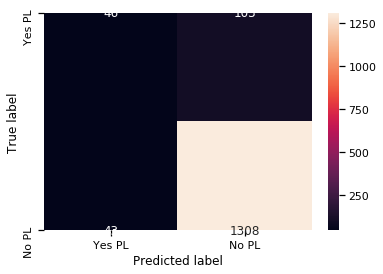

```python
cm=metrics.confusion_matrix(y_test, y_predict, labels=[1, 0])

df_cm = pd.DataFrame(cm, index = [i for i in ["1","0"]],
                  columns = [i for i in ["Predict 1","Predict 0"]])
sns.heatmap(df_cm, annot=True, fmt='.0f', xticklabels = ["Yes PL", "No PL"] , yticklabels = ["Yes PL", "No PL"])
plt.ylabel('True label')
plt.xlabel('Predicted label')
```

```python
df_cm # confusion matrix
```

|  | Predict 1 | Predict 0 |
| --- | --- | --- |
| 1 | 46 | 103 |
| 0 | 43 | 1308 |

# Confusion Matrix Parameters

True Positives (TP): we correctly predicted that they did take the Personal Loan - 46

True Negatives (TN): we correctly predicted that they didnt take the Personal Loan - 1308

False Positives (FP): we incorrectly predicted that they did take the Personal Loan (a "Type I error") 43 Falsely predict positive Type I error

False Negatives (FN): we incorrectly predicted that they didnt take the Personal Loan (a "Type II error") 103 Falsely predict negative Type II error

```python
print(f'Accuracy Score : {accuracy_score(y_test, y_predict)} ')
print(f'Precision Score : {precision_score(y_test, y_predict)}')
print(f'Recall Score : {recall_score(y_test, y_predict)}')
print(f'F1 Score : {f1_score(y_test, y_predict)}')
```

```
Accuracy Score : 0.9026666666666666
Precision Score : 0.5168539325842697
Recall Score : 0.3087248322147651
F1 Score : 0.3865546218487395
```

```python
roc_auc_score(y_test, y_predict)
```

```
0.6384482784315868
```

## Scaling the data using Standard Scaler to improve KNN Performance

```python
# Since KNN is distance based, scaling is important and here Standard performs better than Min-Max
X = pl_data.drop(['ID','Personal Loan'],axis=1)     # Predictor feature columns
y = pl_data['Personal Loan']   # Predicted class (1=True, 0=False)

# Splitting into 30% test data
X_train, X_test, y_train, y_test = train_test_split(X, y, test_size=0.3, random_state=1)
# 1 is just any random seed number

X_train.head()
```

|  | Age | Experience | Income | ZIP Code | Family | CCAvg | Education | Mortgage | Securities Account | CD Account | Online | CreditCard |
| --- | --- | --- | --- | --- | --- | --- | --- | --- | --- | --- | --- | --- |
| 1334 | 47 | 22.0 | 35 | 94304 | 2 | 1.3 | 1 | 0 | 0 | 0 | 1 | 0 |
| 4768 | 38 | 14.0 | 39 | 93118 | 1 | 2.0 | 2 | 0 | 0 | 0 | 1 | 0 |
| 65 | 59 | 35.0 | 131 | 91360 | 1 | 3.8 | 1 | 0 | 0 | 0 | 1 | 1 |
| 177 | 29 | 3.0 | 65 | 94132 | 4 | 1.8 | 2 | 244 | 0 | 0 | 0 | 0 |
| 4489 | 39 | 13.0 | 21 | 95518 | 3 | 0.2 | 2 | 0 | 0 | 0 | 1 | 0 |

```python
# Scaling the data using StandardScaler
scaler = StandardScaler()
X_train_scaled = scaler.fit_transform(X_train)
X_test_scaled = scaler.fit_transform(X_test)
```

```python
# creating odd list of K nearest neighbors for KNN
myList = list(range(1,20))

# subsetting just the odd ones
neighbors = list(filter(lambda x: x % 2 != 0, myList))
```

```python
# empty list that will hold accuracy scores
ac_scores = []

# perform accuracy metrics for values from 1,3,5....19
for k in neighbors:
    knn = KNeighborsClassifier(n_neighbors=k)
    knn.fit(X_train_scaled, y_train)
    # predict the response
    y_predict = knn.predict(X_test_scaled)
    # evaluate accuracy
    scores = accuracy_score(y_test, y_predict)
    ac_scores.append(scores)

# changing to misclassification error
MSE = [1 - x for x in ac_scores]

# determining best k
optimal_k = neighbors[MSE.index(min(MSE))]
print("The optimal number of neighbors is %d" % optimal_k)
```

```
The optimal number of neighbors is 3
```

```python
# instantiate learning model
model = KNeighborsClassifier(n_neighbors = optimal_k)

# fitting the model
model.fit(X_train_scaled, y_train)

# predict the response
y_predict = model.predict(X_test_scaled)
y_predict
```

```
array([0, 0, 0, ..., 0, 0, 0], dtype=int64)
```

```python
model.predict_proba(X_test_scaled)[:,1]# Probability of buying Personal Loan of each customer in dataset
```

```
array([0.33333333, 0.        , 0.        , ..., 0.        , 0.        ,
       0.        ])
```

```python
print("Accuracy on training set: {:.4f}".format(model.score(X_train_scaled, y_train)))
print("Accuracy on test set: {:.4f}".format(model.score(X_test_scaled, y_test)))
```

```
Accuracy on training set: 0.9740
Accuracy on test set: 0.9507
```

Both score are similar for training and test, so no scenario of overfitting or underfitting.

```python
print("Classification Report")
print(metrics.classification_report(y_test, y_predict, labels=[1, 0]))
```

```
Classification Report
              precision    recall  f1-score   support

           1       0.89      0.57      0.70       149
           0       0.95      0.99      0.97      1351

    accuracy                           0.95      1500
   macro avg       0.92      0.78      0.83      1500
weighted avg       0.95      0.95      0.95      1500
```

# The Confusion Matrix

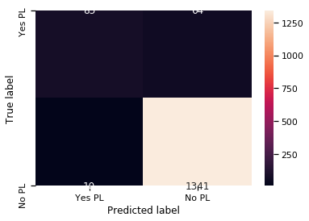

```python
cm=metrics.confusion_matrix(y_test, y_predict, labels=[1, 0])

df_cm = pd.DataFrame(cm, index = [i for i in ["1","0"]],
                  columns = [i for i in ["Predict 1","Predict 0"]])
sns.heatmap(df_cm, annot=True, fmt='.0f', xticklabels = ["Yes PL", "No PL"] , yticklabels = ["Yes PL", "No PL"])
plt.ylabel('True label')
plt.xlabel('Predicted label')
```

```python
df_cm # confusion matrix
```

|  | Predict 1 | Predict 0 |
| --- | --- | --- |
| 1 | 85 | 64 |
| 0 | 10 | 1341 |

# Confusion Matrix Parameters

True Positives (TP): we correctly predicted that they did take the Personal Loan - 85

True Negatives (TN): we correctly predicted that they didnt take the Personal Loan - 1341

False Positives (FP): we incorrectly predicted that they did take the Personal Loan (a "Type I error") 10 Falsely predict positive Type I error

False Negatives (FN): we incorrectly predicted that they didnt take the Personal Loan (a "Type II error") 64 Falsely predict negative Type II error

```python
print(f'Accuracy Score : {accuracy_score(y_test, y_predict)} ')
print(f'Precision Score : {precision_score(y_test, y_predict)}')
print(f'Recall Score : {recall_score(y_test, y_predict)}')
print(f'F1 Score : {f1_score(y_test, y_predict)}')
```

```
Accuracy Score : 0.9506666666666667
Precision Score : 0.8947368421052632
Recall Score : 0.5704697986577181
F1 Score : 0.6967213114754098
```

```python
roc_auc_score(y_test, y_predict)
```

```
0.7815339370786739
```

# Model Evaluation

```
Accuracy of Logistic: 0.908267 (0.007088)
Accuracy of KNN: 0.894667 (0.010541)
Accuracy of NaiveBayes: 0.890533 (0.007452)
```

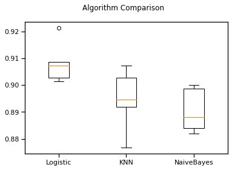

```python
# Accuracy Evaluation

# giving 5 splitting iterations along with 30% test data
splitting = ShuffleSplit(n_splits=5, test_size=0.3, random_state=1)

models = []
models.append(('Logistic', LogisticRegression(solver="liblinear")))
models.append(('KNN', KNeighborsClassifier(n_neighbors = 3)))
models.append(('NaiveBayes', GaussianNB()))
# evaluate each model in turn
results = []
names = []
scoring = 'accuracy' # using accuracy as measure for model evaluation
for name, model in models:
    #kfold = model_selection.KFold(n_splits=10, random_state=12345)
    cv_results = model_selection.cross_val_score(model, X, y, cv=splitting, scoring= scoring)
    results.append(cv_results)
    names.append(name)
    msg = "%s: %f (%f)" % (name, cv_results.mean(), cv_results.std())
    print('Accuracy of ' + msg)
# boxplot algorithm comparison
fig = plt.figure()
fig.suptitle('Algorithm Comparison')
ax = fig.add_subplot(111)
plt.boxplot(results)
ax.set_xticklabels(names)
plt.show()
```

Basing my evaluation on ROC curve score, the Logistic Regression model still performs the best. It is followed by KNN and lastly Naive Bayes. Logistic Regression has ROC curve score of 0.78864, followed by KNN of 3 neighbors of 3 having a 0.78153 score and lastly Naive Bayes having a 0.74452 score. It is interesting to note that for both Logistic Regression and KNN, the performance increased after using Standard Scaling.